# Tutorium 5

Gruppen 2 und 4 Samuel Teuber  
propa@teuber.dev  
https://teuber.dev/propa

# Nachtrag

Normalreihenfolge: Was hat Vorrang? Linkestes oder Äußerstes?

## Advent of Code

Gute Gelegenheit um Haskell, Prolog oder andere Sprache (z.B. Lambda-Kalkül ;) ) zu üben!

www.adventofcode.com

Falls ihr Motivation braucht:  
**Private Leader Board:** `1100658-1030daa6`

Ich selbst arbeite mit Rust

# Aufgabe 1.1

1. `c0 c1 (c2 c3 c4) c5`
2. `(c0 c1 c2) (c3 c4 c5)`
3. `c0 c1 (c2 c3 c4) (c5 c6)`
4. `c0 c1 (c2 c3 c4) c5 c6`
5. `c0 (c1 (c2 c3 c4)) c5 c6`
6. `(λy . c0 c1 c2) (c3 c4 c5)`
7. `(λy . c0 (λz. c1 c2 )) (c3 c4 c5)`

`c0 c1 (c2 c3 c4) c5`

`((c0 c1) ((c2 c3) c4)) c5`

`(c0 c1 c2) (c3 c4 c5)`

`((c0 c1) c2) ((c3 c4) c5)`

`c0 c1 (c2 c3 c4) (c5 c6)`

`((c0 c1) ((c2 c3) c4)) (c5 c6)`

`c0 c1 (c2 c3 c4 ) c5 c6`

`(((c0 c1) ((c2 c3) c4)) c5) c6`

`c0 (c1 (c2 c3 c4)) c5 c6`

`(((c0 (c1 ((c2 c3) c4))) c5) c6)`

`(λy . c0 c1 c2) (c3 c4 c5)`

`(λy . ((c0 c1) c2)) ((c3 c4) c5)`

`(λy . c0 (λz. c1 c2 )) (c3 c4 c5)`

`(λy . (c0 (λz. (c1 c2)))) ((c3 c4) c5)`

# Aufgabe 1.2

Welcher Term repräsentiert den gleichen Term wie `λy . y c0`?

1. `(λy . y ) c0`
2. `λy . (y c0)`

# Aufgabe 1.3

**Substitution:**

1. `x=λy.y` in den Term `(x) c0`
2. `x=(λy.y)` in den Term `x c0`
3. `x=λy.y` in den Term `x c0`

# Aufgabe 1.4

Angenommen `x=c0 c1` welche Aussagen gelten? **Umfrage**

# Aufgabe 1.5

`(λa.a) (λb.b) ((λc.c) ((λd.d) (λe.e) (λf .f ))) (λg .g ) ((λh.h) (λi.i)).`

# Aufgabe 2: Church-Zahlen

```
type Church t = (t -> t) -> t -> t
int2church :: Integer -> Church t
church2int :: Church Integer -> Integer
```

```haskell
type Church t = (t->t) -> t -> t
int2church 0 = \s z -> z
int2church n = \s z -> int2church (n-1) s (s z)

church2int n = n (+1) 0

church2int (int2church 10)
```

```
10
```

# Aufgabe 3

`t1 = (λt. λf. f) ((λy. (λx. x x) (λx. x x)) ((λx. x) (λx. x))) (λt. λf. f)`

`t2 = λy. (λz. (λx. x) (λx. x) z) y`

# Aufgabe 4: Church-Paare

# [Wavelength](https://pp.ipd.kit.edu/lehre/misc/lambda-ide/Wavelength.html)

# Regelsysteme

**Frege'scher Schlussstrich**  
Bekannt aus GBI

# Typsysteme

```
fun6 :: (Enum a, Enum b, Enum c) => a -> b -> c
fun6 x y = succ (toEnum (last [fromEnum x..fromEnum y]))
```

Polymorpher Typ mit Typvariablen `a, b, c`

Auch anwendbar auf **Lambda-Kalkül**!

- Basistypen `bool, int, ...`
- Funktionstypen $\tau_1 \rightarrow \tau_2$ (rechtsassoziativ)
- Typvariablen $\alpha, \alpha_1, \beta, \dots$

# Typsystem: $\Gamma \vdash t : T$

$\Gamma \vdash t : \tau$ im Typkontext $\Gamma$ hat Term $t$ den Typ $\tau$  
$\Gamma$ ordnet freien Variablen x ihre Typen $\Gamma\left(x\right)$ zu

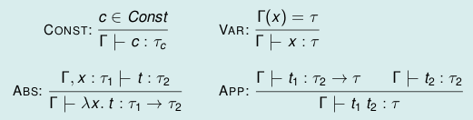

# Beispiel: Typen im Lambdakalkül

pair = $\lambda a.\lambda b.\lambda f. f a b$  
**Typ?**

# Übung: Typherleitung

# Polymorphie

**Typvariablen, Typvariablen, Typvariablen**

## Typschemata

$\forall \alpha_1. \forall \alpha_2. \dots \forall \alpha_n. \tau$  
Steht für unendl. viele Typen mit initialisierten Typvariablen $\alpha_1 \dots \alpha_n$

$\forall \alpha. \alpha \rightarrow \alpha \succeq$ int -> int  
$\forall \alpha. \alpha \rightarrow \alpha \succeq$ bool -> bool

**Problem:** $\lambda f.\ f\ (f\ \texttt{true})$ : ($\alpha$ -> int) -> int

# Angepasste Regeln

### Vorher:

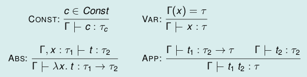

# `let`-Polymorphismus

Für die Typisierung von Ausdrücken wie $\lambda f.\ f\ (f\ \texttt{true})$ : ($\alpha$ -> int) -> int

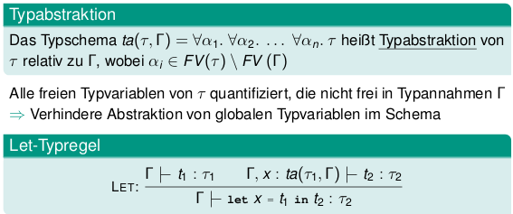